# Welcome to the 5-Minute mzQC interactive guides with python!

This python notebook will guide you through your first steps with reading someone's mzQC in python.

## Setting the scene

First, we need to install the mzQC python library. When outside of the python notebook, find out [here](https://github.com/MS-Quality-hub/pymzqc) how to install locally (spoiler: usually just `pip install pymzqc`).

```python
#@title This will install the latest version of pymzqc
%pip install pymzqc --quiet
%pip install fastobo pronto numpy pandas --quiet
```

Then, we load this right into our python session by loading pymzqc (`from mzqc`). We'll also utilise some other libraries, too. For example, we will use `requests` to load some data from the web.

```python
from mzqc import MZQCFile as qc
import pandas as pd
from io import StringIO
import requests
```

# Acquire data

Next, we need to acquire some data. For demonstration purposes in this notebook we chose a mzQC file from the HUPO-PSI repository. At the end of this notebook, you can upload your own mzQC file to play!

```python
#@title Loading files from the web works only a little different.
response = requests.get('https://github.com/HUPO-PSI/mzQC/raw/refs/tags/v1.0.0/specification_documents/examples/metabo-batches.mzQC')
some_mzqc = qc.JsonSerialisable.from_json(response.text)
```

# Inspect data

We can now go ahead and take a look what that file we loaded has on offer:

```python
print(some_mzqc.description)
```

[output not shown]

**pymzqc** deserialised JSON arrays (i.e. the `runQualities` and their `qualityMetrics`) can be used like python lists:

```python
for m in some_mzqc.runQualities[0].qualityMetrics:
    print(m.name)
```

```
Detected Compounds
```

You can traverse the hierarchy with standard python member access notation (`.`) and get to the bottom of things (like a metric `name` or `value`).

```python
some_mzqc.runQualities[0].qualityMetrics[0].value
```

```
57
```

We can also get the table metrics directly as pandas dataframe! 🤯

```python
from google.colab import data_table
data_table.enable_dataframe_formatter()

df = pd.DataFrame(some_mzqc.setQualities[0].qualityMetrics[0].value)
df
```

|  | Run name | PCA Dimension 1 | PCA Dimension 2 | PCA Dimension 3 | PCA Dimension 4 | PCA Dimension 5 | Injection sequence number | Batch label |
| --- | --- | --- | --- | --- | --- | --- | --- | --- |
| 0 | GCMS ToF sample 10 | -3.348963 | -2.341435 | -1.486755 | -0.276620 | -2.683632 | 13 | 4 |
| 1 | GCMS ToF sample 100 | 0.419126 | 2.055220 | -0.396590 | 1.780880 | -2.020238 | 16 | 7 |
| 2 | GCMS ToF sample 101 | 6.824155 | 1.514235 | 1.163668 | 0.173623 | -3.088806 | 17 | 7 |
| 3 | GCMS ToF sample 102 | -1.080886 | 2.994551 | 0.421837 | 0.013869 | -3.161503 | 18 | 7 |
| 4 | GCMS ToF sample 103 | -1.707045 | 6.070161 | 0.627950 | -0.628732 | -1.064512 | 19 | 7 |
| ... | ... | ... | ... | ... | ... | ... | ... | ... |
| 221 | GCMS ToF sample 95 | 4.246444 | 1.841355 | 0.670941 | 0.938284 | -1.520605 | 11 | 7 |
| 222 | GCMS ToF sample 96 | 2.368072 | 1.001514 | 1.235160 | -0.091535 | -3.000758 | 12 | 7 |
| 223 | GCMS ToF sample 97 | 1.674060 | 0.450211 | -0.512383 | 2.100324 | -1.654505 | 13 | 7 |
| 224 | GCMS ToF sample 98 | -2.928426 | 4.175587 | -0.449582 | 0.333712 | -0.814875 | 14 | 7 |
| 225 | GCMS ToF sample 99 | 10.000164 | 1.918147 | -1.348393 | 0.275859 | 0.749887 | 15 | 7 |

226 rows × 8 columns

# Visualising our data

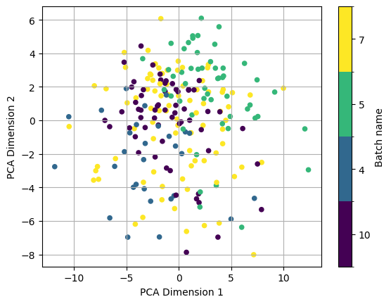

```python
df['Batch name'] = pd.Categorical(df['Batch label'].map(str))
# px.scatter(df, x="PCA Dimension 1", y="PCA Dimension 2", color="Batch name",
                #  hover_name="Run name", hover_data=["Injection sequence number", "Batch label"])
ax = df.plot.scatter(x="PCA Dimension 1", y="PCA Dimension 2", c="Batch name", colormap='viridis')
ax.grid(True)
```

## Your turn!

Select and upload a local file here. Please note that results may vary with uploaded files, given the contents and version of your upload. The remaining cells of the notebook talk you through opening 'local' files.

```python
#@title Upload `.mzQC` file here!
from google.colab import files
try:
  uploaded = files.upload()
except:
  print("If that does not work, proceed with option 2.")

# maybe an alternative?
# from google.colab import drive
# drive.mount('/content/drive')
```

Upload widget is only available when the cell has been executed in the current browser session. Please rerun this cell to enable.

```
Saving example_qc2_longitudinal.mzQC to example_qc2_longitudinal (1).mzQC
```

And then load it as `JsonSerialisable` from file. Note that when using google drive mount in colab or executing this notebook on your local jupyter installation, `from_json` expects a FileHandle, e.g.:

```
with open('/home/user/mzqcs/', 'r') as mzqcfile:
  some_mzqc = qc.JsonSerialisable.from_json(mzqcfile)
```

```python
#@title Provide a file object by `open` either a colab uploaded file or a file path if you are using this notebook locally.
some_mzqc = qc.JsonSerialisable.from_json(next(iter(uploaded.values())).decode())
```

Now you can explore and visualise at your own leisure.